# Pathway analysis with QuSAGE: Replicate vignette

J. Taroni for ALSF CCDL

2019

## Background

Here, we will replicate the [`qusage` package vignette](https://bioconductor.org/packages/release/bioc/vignettes/qusage/inst/doc/qusage.pdf) (Bolen C.). Specifically, we’ll use the same dataset and analysis as the vignette, but the expression data and sample metadata we will use is processed with refine.bio. This allows us to explore formatting refine.bio datasets for use with `qusage` and to compare the results using refine.bio data to the results in the package vignette. We will briefly cover how to obtain gene sets for pathway analysis from the [Molecular Signatures Database (MSigDB)](http://software.broadinstitute.org/gsea/msigdb) as well.

## Pathway analysis

### Set up

```r
# Set seed
set.seed(12345)

`%>%` <- dplyr::`%>%`
```

We need to install `qusage` if we have not already done so. We’ll need `org.Hs.eg.db` as well.

```r
if (!("qusage" %in% installed.packages())) {
  BiocManager::install("qusage", update = FALSE)
}

if (!("org.Hs.eg.db" %in% installed.packages())) {
  BiocManager::install("org.Hs.eg.db", update = FALSE)
}
```

```r
library(org.Hs.eg.db)
library(qusage)
```

Make directories to hold the plots and results.

```r
# Define the file path to the plots directory
plots_dir <- "plots"  # Replace with path to desired output plots directory

# Make a plots directory if it isn't created yet
if (!dir.exists(plots_dir)) {
  dir.create(plots_dir)
}

# Define the file path to the results directory
results_dir <- "results"  # Replace with path to desired output results directory

# Make a results directory if it isn't created yet
if (!dir.exists(results_dir)) {
  dir.create(results_dir)
}

# Define the file path to the data directory
data_dir <- "data"
```

### Gene sets

`qusage` allows you to read in gene sets that are in the [GMT format](http://software.broadinstitute.org/cancer/software/gsea/wiki/index.php/Data_formats#GMT:_Gene_Matrix_Transposed_file_format_.28.2A.gmt.29). [MSigDB](http://software.broadinstitute.org/gsea/msigdb) offers genesets in this format.

We need to download the the MSigDB v6.2 KEGG gene sets that use Entrez gene IDs and placed them at the following relative path:

```
gene-sets/c2.cp.kegg.v6.2.entrez.gmt
```

We can download the file if we don’t find it where we expect!

```r
# the kegg gmt file should be located in the spot we mention above
kegg_file <- file.path("gene-sets", "c2.cp.kegg.v6.2.entrez.gmt")
# since we do not track this file in our repository, let's check to make sure
# it exists where we expect it and download it if we don't find it
if (!file.exists(kegg_file)) {
  message(paste("KEGG GMT file is not found at", kegg_file,
                ", downloading now..."))
  # need gene-sets directory
  if (!dir.exists("gene-sets")) {
    dir.create("gene-sets")
  }
  download.file("https://data.broadinstitute.org/gsea-msigdb/msigdb/release/6.2/c2.cp.kegg.v6.2.entrez.gmt",
                destfile = kegg_file)
}
```

### Conversion to Entrez gene IDs

All refine.bio data uses Ensembl gene IDs. As noted above, the gene sets we’ll be using for our pathway analysis use Entrez gene identifiers. As a result, we’ll need to convert the expression data identifiers to Entrez IDs.

```r
# read in gene expression data
expression_file <- file.path(data_dir,
                             "GSE30550", # Replace with name of the folder in which your expression file is stored
                             "GSE30550.tsv" # Replace with name of your expression file
                             )
exprs_df <- readr::read_tsv(expression_file, progress = FALSE)
# first column is currently named 'Gene' and contains Ensembl gene IDs
colnames(exprs_df)[1] <- "ENSEMBL"
```

We’re using the default behavior for 1:many mappings, where only the first one is selected ([docs](https://www.rdocumentation.org/packages/AnnotationDbi/versions/1.30.1/topics/AnnotationDb-objects)).

```r
entrez_mappings <- mapIds(org.Hs.eg.db, keys = exprs_df$ENSEMBL,
                          column = "ENTREZID", keytype = "ENSEMBL")
```

```r
all.equal(names(entrez_mappings), exprs_df$ENSEMBL)
```

```
[1] TRUE
```

We’ll add this to the `data.frame` of expression data and save to file.

```r
exprs_df <- exprs_df %>%
  dplyr::mutate(ENTREZID = entrez_mappings) %>%
  dplyr::select(ENTREZID, ENSEMBL, dplyr::everything())
readr::write_tsv(exprs_df,
                 path = file.path(data_dir,
                                  "GSE30550", # Replace with name of the folder in which tour expression data is stored
                                  "GSE30550_entrez.tsv" # Replace with name of your expression file containing Entrez gene IDs
                                  ))
```

### Read in metadata and filter

```r
metadata_file <- file.path(data_dir,
                           "GSE30550", # Replace with name of the folder in which your relevant metadata is stored
                           "metadata_GSE30550.tsv" # Replace with name of the metadata file relevant to your expression file
                           )
metadata_df <- readr::read_tsv(metadata_file) %>%
  # drop columns that are all NA
  dplyr::select(-which(apply(is.na(.), 2, all)))
```

In the `qusage` vignette, the authors compared samples 0 hours after exposure to influenza and sample 77 hours after exposure to influenza. We’ll subset to just these samples.

```r
filtered_metadata_df <- metadata_df %>%
  dplyr::filter(time_hpi %in% c("Hour 00", "Hour 077")) %>%
  # the subject & timepoint info are combined in the 'title' column
  dplyr::mutate(subject = stringr::word(title, 1, sep = ","),
                # relabel the timepoints, the lack of spaces will help
                # with the contrast call later
                timepoint = dplyr::case_when(
                  time_hpi == "Hour 00" ~ "t0",
                  time_hpi == "Hour 077" ~ "t1"
                )) %>%
  dplyr::arrange(time_hpi, subject) %>%
  dplyr::select(refinebio_accession_code, subject, refinebio_title, class_blu,
                clinic_pheno, time_hpi, timepoint)
```

```r
time_filtered_exprs <- exprs_df %>%
  dplyr::select(-ENSEMBL) %>%
  # we're reordering samples here to match the metadata ordering
  dplyr::select(ENTREZID, filtered_metadata_df$refinebio_accession_code)
```

Are there duplicated identifiers?

```r
anyDuplicated(time_filtered_exprs$ENTREZID)
```

```
[1] 1187
```

Collapse to duplicated gene identifiers to their mean values.

```r
collapsed_exprs <- time_filtered_exprs %>%
  dplyr::group_by(ENTREZID) %>%
  dplyr::summarise_all(mean) %>%
  # drop unannotated gene
  dplyr::filter(!is.na(ENTREZID))
```

We need to pass `qusage` a matrix. Note that we’re departing a bit from the advice of the authors by refraining from filtering the expression matrix.

```r
exprs_mat <- collapsed_exprs %>%
  tibble::column_to_rownames("ENTREZID") %>%
  as.matrix()
```

Let’s get rid of some of the objects in the workspace we don’t need.

```r
rm(collapsed_exprs, time_filtered_exprs, exprs_df, metadata_df)
```

### Read in gene sets

```r
kegg_genesets <- read.gmt(kegg_file)
```

### Perform pathway analysis

```r
timepoint_qusage_results <- qusage(eset = exprs_mat,
                                   labels = filtered_metadata_df$timepoint,
                                   contrast = "t1-t0",
                                   geneSets = kegg_genesets)
```

```
Aggregating gene data for gene sets......................................Done.
Calculating variance inflation factors...Done.
```

We can look at the results with the `qsTable` function. This will give us the top 20 pathways by default. (This can be changed via the `number` argument to `qsTable`.)

```r
qsTable(timepoint_qusage_results)
```

|  | pathway.name | log.fold.change | p.Value | FDR |
| --- | --- | --- | --- | --- |
| 135 | KEGG_CIRCADIAN_RHYTHM_MAMMAL | -0.17328686 | 6.471849e-05 | 0.004284686 |
| 158 | KEGG_VIBRIO_CHOLERAE_INFECTION | -0.68681244 | 8.040701e-05 | 0.004284686 |
| 97 | KEGG_SNARE_INTERACTIONS_IN_VESICULAR_TRANSPORT | 0.29220364 | 8.265727e-05 | 0.004284686 |
| 129 | KEGG_T_CELL_RECEPTOR_SIGNALING_PATHWAY | -0.38740146 | 1.087025e-04 | 0.004284686 |
| 184 | KEGG_ARRHYTHMOGENIC_RIGHT_VENTRICULAR_CARDIOMYOPATHY_ARVC | -0.44127972 | 1.281280e-04 | 0.004284686 |
| 116 | KEGG_ADHERENS_JUNCTION | -0.73325017 | 1.553251e-04 | 0.004284686 |
| 185 | KEGG_DILATED_CARDIOMYOPATHY | -0.31166567 | 1.861561e-04 | 0.004284686 |
| 150 | KEGG_ALDOSTERONE_REGULATED_SODIUM_REABSORPTION | -0.22396046 | 2.151739e-04 | 0.004284686 |
| 3 | KEGG_PENTOSE_PHOSPHATE_PATHWAY | -1.74845617 | 2.539077e-04 | 0.004284686 |
| 113 | KEGG_FOCAL_ADHESION | -0.31011059 | 2.808553e-04 | 0.004284686 |

[output cut: 10 more lines]

Let’s save the results to file. First, let’s save a nicely formatted table.

```r
timepoint_table <- qsTable(timepoint_qusage_results,
                           # numPathways let's us snag all tested gene sets
                           number = numPathways(timepoint_qusage_results))
readr::write_tsv(timepoint_table,
                 file.path(results_dir,"qusage_t1-t0_kegg_results.tsv"))
```

Note that gene sets with negative fold changes are higher in `t0`.

We’re also going to save the `QSarray` output of `qusage` because, as we’ll see shortly, there’s lots you can do with qusage results!

```r
readr::write_rds(timepoint_qusage_results,
                 file.path(results_dir, "qusage_t1-t0_kegg_QSarray.RDS"))
```

#### Plotting

We can look at the overall results with the `plotCIs` function.

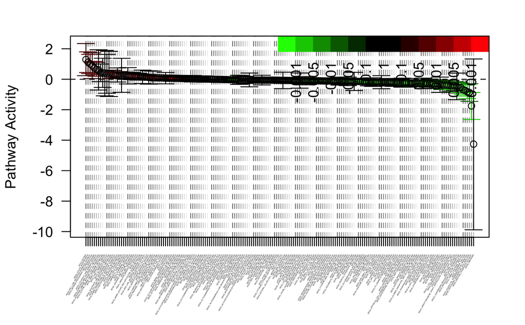

```r
plotCIs(timepoint_qusage_results, cex.xaxis = 0.25)
```

It’s a bit difficult to see in this notebook, but we’ll save the plot as a PDF.

```r
pdf(file.path(plots_dir, "qusage_t1-t0_plotCIs.pdf"), width = 14, height = 8)
# adjusting the figure margins to better fit pathway names
par(mar = c(8, 4, 1, 2))
plotCIs(timepoint_qusage_results, cex.xaxis = 0.5)
dev.off()
```

Let’s look more closely at the T Cell Receptor Signaling Pathway. We can see above that this pathway has a negative fold change and therefore should be higher at `t0`.

```r
pathway_index <-
  which(names(kegg_genesets) == "KEGG_T_CELL_RECEPTOR_SIGNALING_PATHWAY") # Replace with exact name of desired pathway -- names of pathways can be seen using the `names(kegg_genesets)` function
```

Plot the overall distribution of the pathway (thick black line) and the distribution of the individual genes (thin lines colored by their standard deviations).

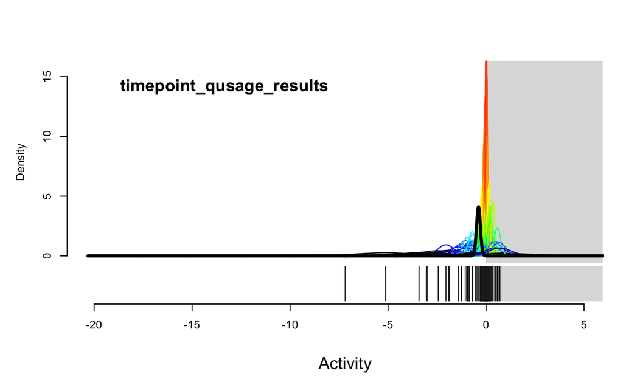

```r
plotGeneSetDistributions(timepoint_qusage_results, path.index = pathway_index)
```

We can see the majority of genes in this pathway don’t change much, but a handful have lower values in `t1`.

Now, plot the mean and confidence intervals for each gene in the pathway. This gives us insight into *which* genes changed the most.

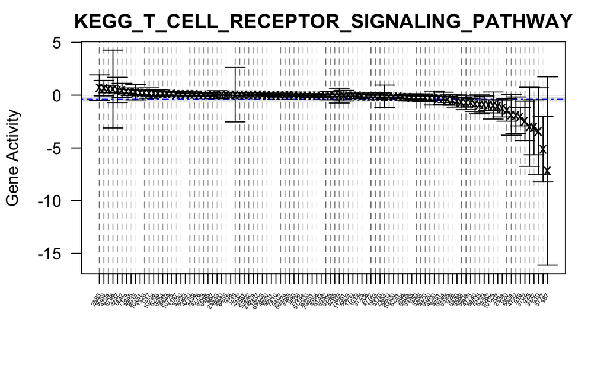

```r
plotCIsGenes(timepoint_qusage_results, path.index = pathway_index,
             cex.xaxis = 0.75)
```

We can easily check to see if the directionality is as we expect by making a boxplot of the gene `387` which has a negative value and is on right side of the graph.

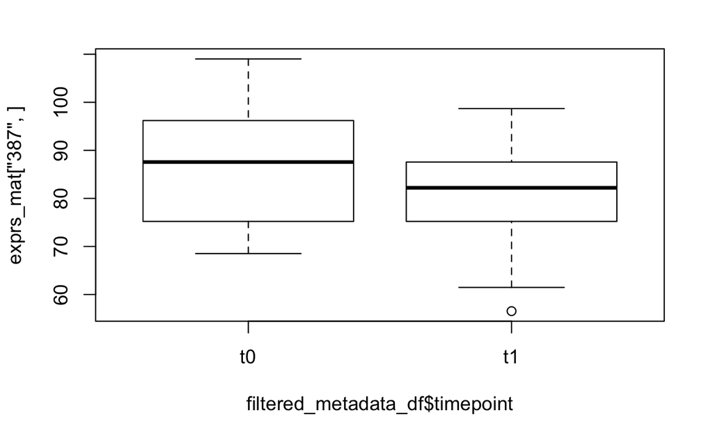

```r
graphics::boxplot(exprs_mat["387", ] ~ filtered_metadata_df$timepoint)
```